# Clase 09 - Guía Análisis de varianza y posteriores

OCE 386 - Introducción al análisis de datos con R.

Dr. José Gallardo Matus

Pontificia Universidad Católica de Valparaíso  
jose.gallardo@pucv.cl

04 October 2021

#### **Introducción**

**Análisis de Varianza**

Es una herramienta de inferencia estadística muy usada en el campo de investigación científico-técnica de las ciencias biológicas y en particular en la acuicultura. El ANOVA es un método estadístico cuya finalidad es probar hipótesis referidas a los parámetros de posición de dos o más poblaciones en estudio.

**Comparación a posteriori**

Existen diversas pruebas a posteriori para analizar el porque se rechaza la hipotesis nula que se está considerando en nuestro estudio; es decir, si rechazamos la hipótesis nula del ANOVA, la pregunta que podríamos hacernos es la siguiente **¿cuál o cuáles de las medias poblacionales en estudio son las diferentes?** Existen diversas pruebas a posteriori para analizar está problemática; no obstante, en esta guía usaremos la *prueba de Tukey*.

#### **Objetivos de aprendizaje**

Los objetivos de aprendizaje de esta guía son:

**1**. - Elaborar hipótesis estadísticas.

**2**. - Realizar análisis de varianza y comparaciones a posteriori.

**3**. - Elaborar un reporte dinámico en formato pdf con **[Rmarkdown](https://rmarkdown.rstudio.com/)**.

#### **Comandos**

A continuación, se presentan algunos comandos que deberá usar para resolver los ejercicios de esta guía.

**1.-** **lm():** se utiliza para ajustar modelos lineales. También, se puede utilizar para realizar regresiones, análisis de varianza de un factor o dos factores de clasificación (se puede considerar interacción entre los factores) y análisis de covarianza (aunque aov puede proporcionar una interfaz más conveniente para el ANOVA).

**2.-** **aov():** se usa para ajustar un modelo de análisis de varianza.

**3.-** **anova():** se usa para hacer un ANOVA sobre el objeto obtenido al ajustar un modelo con las funciones lm() o aov().

**4.-** **TukeyHSD():** se usa para hacer la prueba a posteriori de Tukey.

**Nota:** La prueba Tukey trabaja sobre un objeto *aov*, no sobre un objeto lm.

### **Ejercicio 1.** **Elaborar archivo Rmarkdown**

Usando lo aprendido en la unidad 1 del curso elabore y configure un archivo o file con extensión **.Rmd** y configúrelo para exportar el resultado como un documento dinámico **pdf**.

Incluya en metadatos: Título: Reporte Anova y posteriores, nombre del autor: Su nombre.

Luego guarde inmediatamente su *script* como **script_09_nombre_apellido.Rmd**. Al finalizar la actividad deberá exportar y almacenar este script tareas de aula virtual.

### **Ejercicio 2.** **Configuración del reporte**

En el primer bloque de códigos o **chunk** configure los comandos de la siguiente manera *knitr::opts_chunk$set(echo = TRUE)* y cargue las librerías **stats**, **graphics**, **ggplot2**, **readxl**, **pander**, **dplyr** y **knitr**.

```r
knitr::opts_chunk$set(echo = TRUE)

# Librería stats está instalada por defecto en la base de R
library(stats)

# Librería graphics está instalada por defecto en la base de R
library(graphics)

# Librería para gráficas avanzadas
library(ggplot2)

# Librería para importar datos
library(readxl)

# Librería para mostrar en formato tabla los resultados de un objeto
library(pander)

# Librería para usar funciones de tidyverse
library(dplyr)

# Librería para hacer tablas
library(knitr)
```

### **Ejercicio 3.** **Anova de un factor con dos niveles**

La base de datos **Peces_intermareales_data.xlsx** contiene información del peso de cuerpo **(Body_Weight_g)** y **Especie** de 200 peces intermareales. Los investigadores desean evaluar si las especies **Torito** (*Scartichthys viridis*) y (*Hypsoblennius sordidus*) difieren en su tamaño. Datos simulados a partir de información estadística publicada por [Quijada y Caceres, 2000](http://rchn.biologiachile.cl/pdfs/2000/4/Quijada_%26_Caceres_2000.pdf)

**a).** Formule la hipótesis nula y alternativa para este experimento.

```r
#**H~0~**: $$ \mu_{Torito} = \mu_{Hypsoblennius sordidus}$$

#**H~1~**: $$ \mu_{Torito} \ne \mu_{Hypsoblennius sordidus}$$
```

**b).** Importe el set de datos **Peces_intermareales_data.xlsx** usando la función **read_excel()** de la librería **readxl**, llame al objeto Peces_intermareales. Transformar en factor la variable Especie con la función **as.factor()**. Explore el set de datos usando las funciones **head()**, **str()** y **summary()**.

```r
Peces_intermareales <- read_excel("Peces_intermareales_data.xlsx")
Peces_intermareales$Especie <- as.factor(Peces_intermareales$Especie)
head(Peces_intermareales)
```

```
## # A tibble: 6 x 3
##      ID Especie `Body Weight (g)`
##   <dbl> <fct>               <dbl>
## 1     1 Torito              15.5
## 2     2 Torito              15.5
## 3     3 Torito              25.6
## 4     4 Torito               6.12
## 5     5 Torito               8.26
## 6     6 Torito              11.5
```

```r
str(Peces_intermareales)
```

```
## tibble [200 × 3] (S3: tbl_df/tbl/data.frame)
##  $ ID             : num [1:200] 1 2 3 4 5 6 7 8 9 10 ...
##  $ Especie        : Factor w/ 2 levels "Cachudito","Torito": 2 2 2 2 2 2 2 2 2 2 ...
##  $ Body Weight (g): num [1:200] 15.55 15.55 25.58 6.12 8.26 ...
```

```r
summary(Peces_intermareales)
```

```
##        ID              Especie    Body Weight (g)
##  Min.   :  1.00   Cachudito:100   Min.   : 1.686
##  1st Qu.: 50.75   Torito   :100   1st Qu.: 8.274
##  Median :100.50                   Median :13.222
##  Mean   :100.50                   Mean   :13.471
##  3rd Qu.:150.25                   3rd Qu.:17.425
##  Max.   :200.00                   Max.   :33.039
```

**c).** Realice un análisis exploratorio de datos de la variable bajo estudio. A partir del objeto **Peces_intermareales** elabore un gráfico de cajas y bigotes para la variable **Body Weight (g)**. Use el comando tuberías **%>%** de la librería **dplyr**. Etiquete los ejes y de un nombre a la figura.

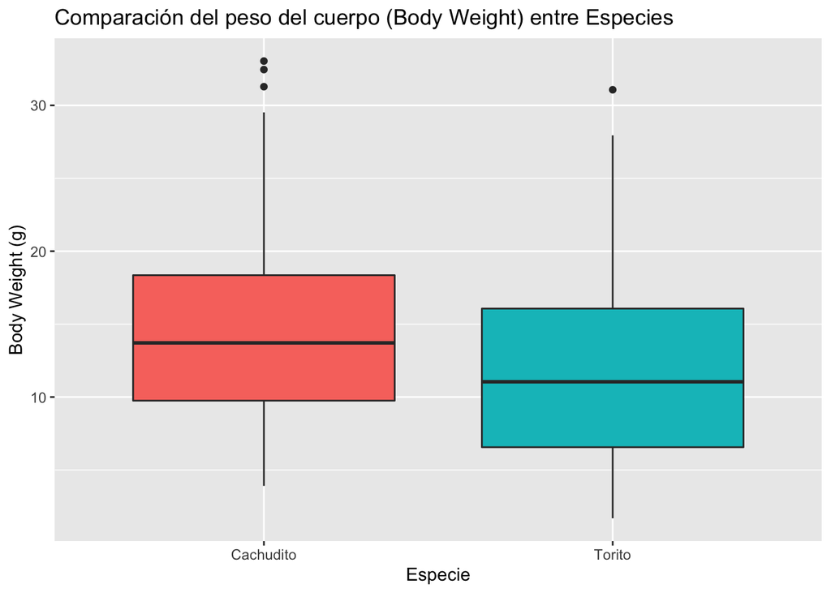

```r
Peces_intermareales %>%
          ggplot(aes(x= Especie,y=`Body Weight (g)`,fill=Especie))+
                geom_boxplot()+
                theme(legend.position="none")+
                labs(x="Especie",y="Body Weight (g)",title="Comparación del peso del cuerpo (Body Weight) entre Especies")
```

**d).** Incluya una tabla con los estimadores puntuales de los promedios y las varianzas de la variable Body Weight (g) para cada nivel del factor Especie. Use las funciones **filter**, **summarize** y **%>%** de la librería dplyr para calcular los estimadores. Use el comando **knitr::kable()** para generar la tabla.

Promedio y varianza de la variable Body Weight para la Especie Torito.

```r
Torito <- Peces_intermareales %>%
                             filter(Especie == "Torito") %>%
summarize(`Media Torito`= mean(`Body Weight (g)`),
          `Varianza Torito`= var(`Body Weight (g)`))

Torito
```

```
## # A tibble: 1 x 2
##   `Media Torito` `Varianza Torito`
##            <dbl>             <dbl>
## 1           12.2              46.9
```

Promedio y varianza de la variable Body Weight para la Especie Cachudito.

```r
Cachudito <- Peces_intermareales %>%
                        filter(Especie == "Cachudito") %>%
summarize(`Media Cachudito`= mean(`Body Weight (g)`),
          `Varianza Cachudito`= var(`Body Weight (g)`))

Cachudito
```

```
## # A tibble: 1 x 2
##   `Media Cachudito` `Varianza Cachudito`
##               <dbl>                <dbl>
## 1              14.7                 44.7
```

Tabla resumen.

```r
Tabla <- data.frame(Torito, Cachudito)
colnames(Tabla) <- c("Media Torito","Varianza Torito", "Media Cachudito","Varianza Cachudito")

knitr::kable(Tabla,caption ="Medias y varianzas de la variable Body Weight (g) para las Especies Torito y Cachudito")
```

Medias y varianzas de la variable Body Weight (g) para las Especies Torito y Cachudito

| Media Torito | Varianza Torito | Media Cachudito | Varianza Cachudito |
| --- | --- | --- | --- |
| 12.23232 | 46.93097 | 14.70992 | 44.73358 |

**e).** Realice el ajuste del siguiente modelo usando la función aov(), donde los parámetros son los siguientes: variable respuesta **Body Weight (g)** y como factor de clasificación **Especie**, como set de datos (data=Peces intermareales). Llame al objeto anova1. Utilice el simbolo ~ para relacionar la variable respuesta con el factor de clasificación. Luego, realice el anova() del objeto anova1.

```r
anova1 <- aov(`Body Weight (g)` ~ Especie, data=Peces_intermareales)
anova(anova1)
```

```
## Analysis of Variance Table
##
## Response: Body Weight (g)
##            Df Sum Sq Mean Sq F value  Pr(>F)
## Especie     1  306.9 306.926  6.6967 0.01037 *
## Residuals 198 9074.8  45.832
## ---
## Signif. codes:  0 '***' 0.001 '**' 0.01 '*' 0.05 '.' 0.1 ' ' 1
```

Use la función pander::pander() para mostrar los resultados del modelo (anova1) en una tabla.

```r
pander::pander(anova1, caption = "ANOVA a una vía de clasificación usando la función aov().")
```

ANOVA a una vía de clasificación usando la función aov().

|  | Df | Sum Sq | Mean Sq | F value | Pr(>F) |
| --- | --- | --- | --- | --- | --- |
| **Especie** | 1 | 306.9 | 306.9 | 6.697 | 0.01037 |
| **Residuals** | 198 | 9075 | 45.83 | NA | NA |

**f).** Interprete los resultados.

```r
#El efecto Especie es estadísticamente significativo (p valor menor al nivel de significación del 5%). En consecuencia se rechaza la hipótesis nula. Por lo tanto, existen diferencias entre los pesos finales promedios de las Especie Torito y Cachudito.
```

### **Ejercicio 4.** **Anova de dos factores y prueba a Posteriori Tukey**

Las variables de estudio se describen a continuación:

| **variable** | **Descripción** | **Tipo de efecto** |
| --- | --- | --- |
| **Pez** | Identificador del pez | Criterio de clasificación |
| **feed** | 6 tipos de dietas | Variable explicativa |
| **sex** | Sexo del pez | Variable explicativa |
| **weight** | Peso en gramos. | Variable respuesta |

**a).** Formule la hipótesis nula y alternativa para evaluar si el peso es el mismo entre los peces con distinto sexo y alimentados con diferente dieta.

```r
#**H~0~**: $$\mu_{Macho_d1} = \mu_{Macho_d2} = \mu_{Macho_d3} = \mu_{Macho_d4} = \mu_{Macho_d5} = \mu_{Macho_d6}$$ = $$\mu_{Hembra_d1} = \mu_{Hembra_d2} = \mu_{Hembra_d3} = \mu_{Hembra_d4} = \mu_{Hembra_d5} = \mu_{Hembra_d6}$$

#**H~1~**: Al menos una de las medias del peso es diferente para cada dieta en cada sexo.
```

**b)** Importe el set de datos **dietas.xslx** usando la función **read_excel()** de la librería **readxl**.

Transforme a factor las columnas **pez**, **feed** y **sex** con la función **as.factor()**. Luego, explore el set de datos usando la función **summary()** y explore los factores **feed** y **sex** con la función **table()**.

```r
dietas <- read_excel("dietas.xlsx")
dietas$pez<- as.factor(dietas$pez)
dietas$feed<- as.factor(dietas$feed)
dietas$sex<- as.factor(dietas$sex)
summary(dietas)
```

```
##       pez     feed        sex         weight
##  1      : 1   d1:12   Hembra:54   Min.   :103.0
##  2      : 1   d2:10   Macho :17   1st Qu.:204.5
##  3      : 1   d3:12               Median :259.0
##  4      : 1   d4:11               Mean   :261.1
##  5      : 1   d5:14               3rd Qu.:325.5
##  6      : 1   d6:12               Max.   :418.0
##  (Other):65
```

```r
table(dietas$feed, dietas$sex)
```

```
##
##      Hembra Macho
##   d1      9     3
##   d2      7     3
##   d3      8     4
##   d4      9     2
##   d5     11     3
##   d6     10     2
```

**c).** Realice un análisis exploratorio de datos de la variable bajo estudio. A partir del set de datos de elabore un gráfico de cajas y bigotes las funciones **ggplot** y **geom_boxplot()** para la variable **weight**, como criterios de clasificación use dietas y sexo, particine la gráfica en dos paneles usando usando **facet_wrap(~ sex)**.

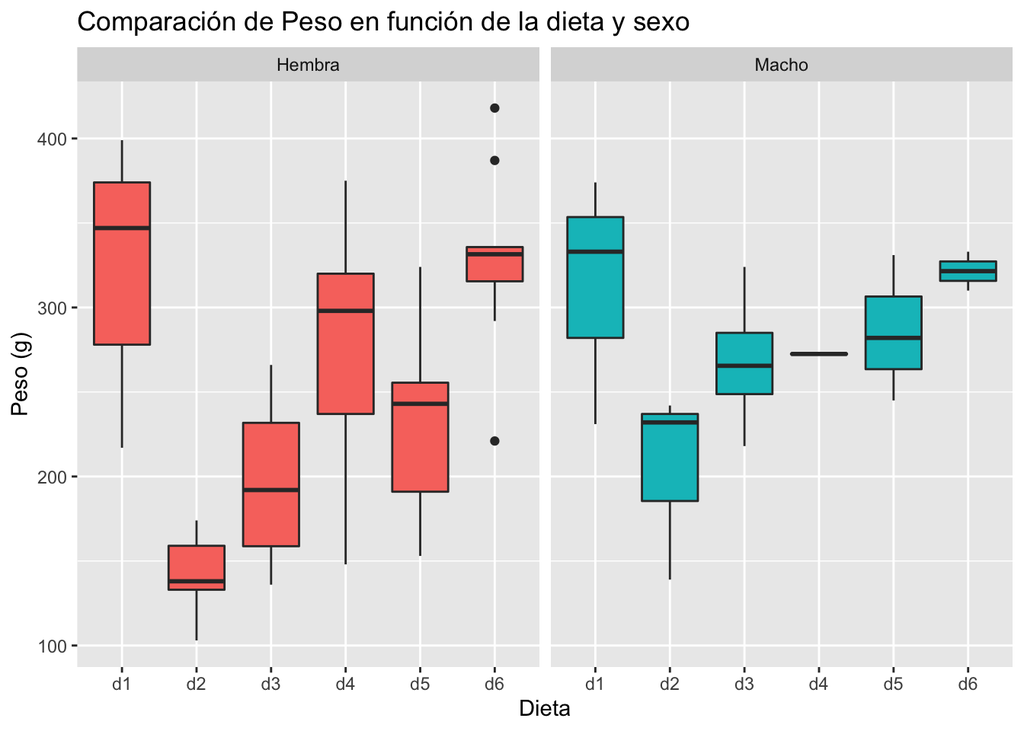

```r
dietas %>%
                ggplot(aes(x= feed,y=weight,fill=sex))+
                geom_boxplot()+
                theme(legend.position="none")+
                labs(x="Dieta",y="Peso (g)",title="Comparación de Peso en función de la dieta y sexo")+
                facet_wrap(~ sex)
```

**d)** Realice ahora una gráfica de interacción y una gráfica de tamaño de los efectos de la variable *weight* usando las funcines **interaction.plot()** y **plot.design()**. Incluya *feed* y *sex* como factores.

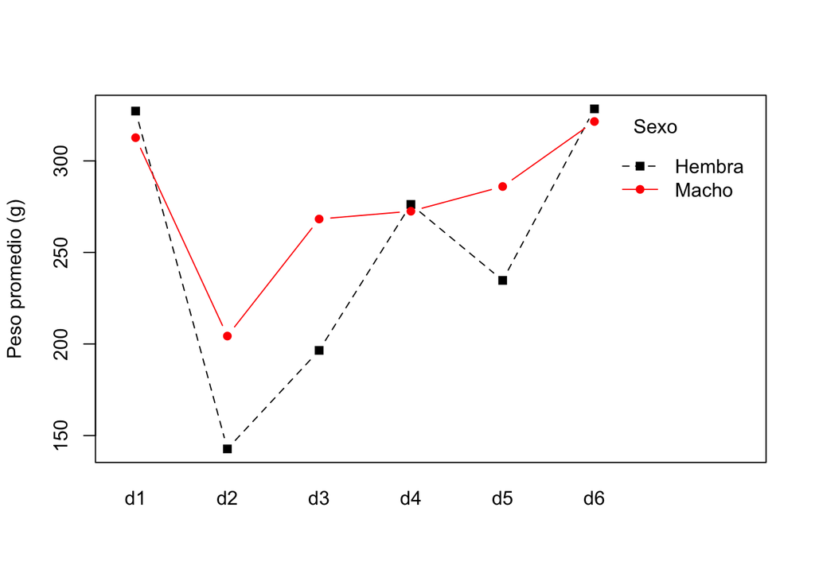

```r
interaction.plot(dietas$feed, dietas$sex, dietas$weight, fun = mean, xlab = "", ylab = "Peso promedio (g)", col=1:2, trace.label="Sexo", pch = c(15, 16), type = "b")
```

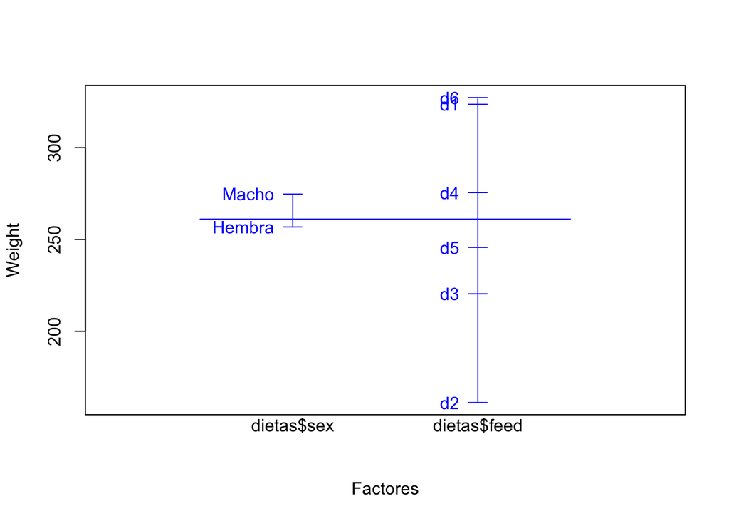

```r
plot.design(dietas$weight~ dietas$sex * dietas$feed, xlab = "Factores", ylab="Weight", col="blue")
```

**e).** Realice el ajuste del siguiente modelo usando la función aov(), donde los parámetros son los siguientes: variable respuesta **weight** y como factores de clasificación **feed** y **sex**, como set de datos (data=dietas). Llame al objeto anova2. Utlice el simbolo ~ para relacionar la variable respuesta con los factores de clasificación y su interacción. Realice el anova() del objeto anova2. Use la función pander::pander() para mostrar los resultados del modelo (anova2), coloque en el parámetro caption un título a la tabla.

```r
anova2 <- aov(weight ~ feed*sex, data=dietas)
```

```r
anova(anova2)
```

```
## Analysis of Variance Table
##
## Response: weight
##           Df Sum Sq Mean Sq F value   Pr(>F)
## feed       5 224631   44926 14.9199 1.88e-09 ***
## sex        1  12075   12075  4.0102  0.04983 *
## feed:sex   5  16402    3280  1.0894  0.37578
## Residuals 59 177658    3011
## ---
## Signif. codes:  0 '***' 0.001 '**' 0.01 '*' 0.05 '.' 0.1 ' ' 1
```

```r
pander::pander(anova2, caption = "ANOVA a dos vías de clasificación usando la función aov().")
```

ANOVA a dos vías de clasificación usando la función aov().

|  | Df | Sum Sq | Mean Sq | F value | Pr(>F) |
| --- | --- | --- | --- | --- | --- |
| **feed** | 5 | 224631 | 44926 | 14.92 | 1.88e-09 |
| **sex** | 1 | 12075 | 12075 | 4.01 | 0.04983 |
| **feed:sex** | 5 | 16402 | 3280 | 1.089 | 0.3758 |
| **Residuals** | 59 | 177658 | 3011 | NA | NA |

**f).** Realice una prueba *a posteriori* de Tukey sobre el objeto anova2. Para esto use la función **TukeyHSD()**. Note que dado que no hay un efecto significativo de interacción debe crear un nuevo modelo de anova aov(weight ~ feed + sex, data=dietas) antes de ejecutar el test de tukey.

Nueva anova

```r
anova3 <- aov(weight ~ feed + sex, data=dietas)
anova(anova3)
```

```
## Analysis of Variance Table
##
## Response: weight
##           Df Sum Sq Mean Sq F value    Pr(>F)
## feed       5 224631   44926 14.8164 1.212e-09 ***
## sex        1  12075   12075  3.9824   0.05024 .
## Residuals 64 194060    3032
## ---
## Signif. codes:  0 '***' 0.001 '**' 0.01 '*' 0.05 '.' 0.1 ' ' 1
```

Prueba de tukey

```r
Tukey_anova3 <- TukeyHSD(anova3)
Tukey_anova3
```

```
##   Tukey multiple comparisons of means
##     95% family-wise confidence level
##
## Fit: aov(formula = weight ~ feed + sex, data = dietas)
##
## $feed
##              diff        lwr       upr     p adj
## d2-d1 -162.383333 -231.64974 -93.11692 0.0000000
## d3-d1 -103.166667 -169.20960 -37.12374 0.0002978
## d4-d1  -48.037879 -115.56511  19.48935 0.3055824
## d5-d1  -77.869048 -141.50961 -14.22849 0.0079599
## d6-d1    3.666667  -62.37626  69.70960 0.9999832
## d3-d2   59.216667  -10.04974 128.48308 0.1360724
## d4-d2  114.345455   43.66241 185.02850 0.0001662
## d5-d2   84.514286   17.53453 151.49404 0.0056424
## d6-d2  166.050000   96.78359 235.31641 0.0000000
## d4-d3   55.128788  -12.39844 122.65602 0.1722980
## d5-d3   25.297619  -38.34294  88.93818 0.8503292
## d6-d3  106.833333   40.79040 172.87626 0.0001664
## d5-d4  -29.831169  -95.01076  35.34842 0.7591378
## d6-d4   51.704545  -15.82268 119.23177 0.2302585
## d6-d5   81.535714   17.89515 145.17628 0.0047239
##
## $sex
##                  diff        lwr      upr     p adj
## Macho-Hembra 30.26004 -0.3329932 60.85308 0.0524706
```

**g).** Interprete los resultados respondiendo las siguientes preguntas.

- ¿Cuál de los dos factores (dietas o sexo) tiene mayor influencia en la variable respuesta?
- ¿Entre que dietas existen diferencias significativas?
- ¿Observa algún patrón claro de interacción entre sex y feed?
- ¿La interacción es significativa?

```r
# Con el modelo de interacción  tanto dieta como sexo tienen un efecto signifiativo sobre el peso de los animales. Sin embargo, al eliminar el efecto de interacción el efecto sexo no es significativo.

# Existen diferencias significativas entre d2-d1, d3-d1, d5-d1, d4-d2, d5-d2, d6-d2, d6-d3 y d6-d5.

# La grafica d einteracción no muestra un claro efecto, y tampoco se comprueba un efecto con el test estadistico aplicado.
```